# Proyecto final - Análisis de ventas de videojuegos

```
# Miguel Rodriguez Florez - Ingeniería de sistemas
# Universidad EAN - 2026
```

Para este proyecto decidí trabajar con un dataset de ventas globales de videojuegos, que reúne información de más de 16.000 títulos lanzados entre 1980 y 2020, incluyendo plataforma, género, publisher, año de lanzamiento y ventas por región (Norteamérica, Europa, Japón y el resto del mundo).

Elegí este dataset por dos razones. Primero, siempre me han gustado los videojuegos, así que me pareció una buena oportunidad de analizar algo que realmente me interesa en lugar de trabajar con datos cualquiera. Y segundo, porque desde la carrera de ingeniería de sistemas, este tipo de datos me sirve para practicar justo lo que se necesita en cualquier proceso de análisis: entender cómo vienen los datos "crudos", detectar qué está mal (columnas incompletas, formatos raros, duplicados) y dejarlos listos para poder sacar conclusiones útiles.

Además, este dataset tiene un plus interesante para el ejercicio: no está perfectamente limpio. Tiene valores nulos en columnas como el año de lanzamiento o el publisher, lo que lo hace ideal para aplicar procesos reales de limpieza y no solo trabajar con datos que ya vienen impecables. Esto se parece bastante a lo que pasa en cualquier trabajo real, siempre hay que revisar los datos.

## Carga y exploración de datos

```python
import pandas as pd
import matplotlib.pyplot as plt
import seaborn as sns

url = "https://raw.githubusercontent.com/CodingwithO/VideoGameSales/master/vgsales.csv"
df = pd.read_csv(url)

print("Dimensiones del dataset:", df.shape)
print("\nColumnas:", df.columns.tolist())
df.head(20)
```

```
Dimensiones del dataset: (16598, 11)

Columnas: ['Rank', 'Name', 'Platform', 'Year', 'Genre', 'Publisher', 'NA_Sales', 'EU_Sales', 'JP_Sales', 'Other_Sales', 'Global_Sales']
```

|  | Rank | Name | Platform | Year | Genre | Publisher | NA_Sales | EU_Sales | JP_Sales | Other_Sales | Global_Sales |
| --- | --- | --- | --- | --- | --- | --- | --- | --- | --- | --- | --- |
| 0 | 1 | Wii Sports | Wii | 2006.0 | Sports | Nintendo | 41.49 | 29.02 | 3.77 | 8.46 | 82.74 |
| 1 | 2 | Super Mario Bros. | NES | 1985.0 | Platform | Nintendo | 29.08 | 3.58 | 6.81 | 0.77 | 40.24 |
| 2 | 3 | Mario Kart Wii | Wii | 2008.0 | Racing | Nintendo | 15.85 | 12.88 | 3.79 | 3.31 | 35.82 |
| 3 | 4 | Wii Sports Resort | Wii | 2009.0 | Sports | Nintendo | 15.75 | 11.01 | 3.28 | 2.96 | 33.00 |
| 4 | 5 | Pokemon Red/Pokemon Blue | GB | 1996.0 | Role-Playing | Nintendo | 11.27 | 8.89 | 10.22 | 1.00 | 31.37 |
| 5 | 6 | Tetris | GB | 1989.0 | Puzzle | Nintendo | 23.20 | 2.26 | 4.22 | 0.58 | 30.26 |
| 6 | 7 | New Super Mario Bros. | DS | 2006.0 | Platform | Nintendo | 11.38 | 9.23 | 6.50 | 2.90 | 30.01 |
| 7 | 8 | Wii Play | Wii | 2006.0 | Misc | Nintendo | 14.03 | 9.20 | 2.93 | 2.85 | 29.02 |
| 8 | 9 | New Super Mario Bros. Wii | Wii | 2009.0 | Platform | Nintendo | 14.59 | 7.06 | 4.70 | 2.26 | 28.62 |
| 9 | 10 | Duck Hunt | NES | 1984.0 | Shooter | Nintendo | 26.93 | 0.63 | 0.28 | 0.47 | 28.31 |
| 10 | 11 | Nintendogs | DS | 2005.0 | Simulation | Nintendo | 9.07 | 11.00 | 1.93 | 2.75 | 24.76 |
| 11 | 12 | Mario Kart DS | DS | 2005.0 | Racing | Nintendo | 9.81 | 7.57 | 4.13 | 1.92 | 23.42 |
| 12 | 13 | Pokemon Gold/Pokemon Silver | GB | 1999.0 | Role-Playing | Nintendo | 9.00 | 6.18 | 7.20 | 0.71 | 23.10 |
| 13 | 14 | Wii Fit | Wii | 2007.0 | Sports | Nintendo | 8.94 | 8.03 | 3.60 | 2.15 | 22.72 |
| 14 | 15 | Wii Fit Plus | Wii | 2009.0 | Sports | Nintendo | 9.09 | 8.59 | 2.53 | 1.79 | 22.00 |
| 15 | 16 | Kinect Adventures! | X360 | 2010.0 | Misc | Microsoft Game Studios | 14.97 | 4.94 | 0.24 | 1.67 | 21.82 |
| 16 | 17 | Grand Theft Auto V | PS3 | 2013.0 | Action | Take-Two Interactive | 7.01 | 9.27 | 0.97 | 4.14 | 21.40 |
| 17 | 18 | Grand Theft Auto: San Andreas | PS2 | 2004.0 | Action | Take-Two Interactive | 9.43 | 0.40 | 0.41 | 10.57 | 20.81 |
| 18 | 19 | Super Mario World | SNES | 1990.0 | Platform | Nintendo | 12.78 | 3.75 | 3.54 | 0.55 | 20.61 |
| 19 | 20 | Brain Age: Train Your Brain in Minutes a Day | DS | 2005.0 | Misc | Nintendo | 4.75 | 9.26 | 4.16 | 2.05 | 20.22 |

```python
print("Tipos de datos")
print(df.dtypes)
print("\nValores nulos por columna")
print(df.isnull().sum())
print("\nDuplicados exactos")
print(df.duplicated().sum())
print("\nResumen estadístico")
df.describe(include='all')
```

```
Tipos de datos
Rank              int64
Name                str
Platform            str
Year            float64
Genre               str
Publisher           str
NA_Sales        float64
EU_Sales        float64
JP_Sales        float64
Other_Sales     float64
Global_Sales    float64
dtype: object

Valores nulos por columna
Rank              0
Name              0
Platform          0
Year            271
Genre             0
Publisher        58
NA_Sales          0
EU_Sales          0
JP_Sales          0
Other_Sales       0
Global_Sales      0
dtype: int64

Duplicados exactos
0

Resumen estadístico
```

|  | Rank | Name | Platform | Year | Genre | Publisher | NA_Sales | EU_Sales | JP_Sales | Other_Sales | Global_Sales |
| --- | --- | --- | --- | --- | --- | --- | --- | --- | --- | --- | --- |
| count | 16598.000000 | 16598 | 16598 | 16327.000000 | 16598 | 16540 | 16598.000000 | 16598.000000 | 16598.000000 | 16598.000000 | 16598.000000 |
| unique | NaN | 11493 | 31 | NaN | 12 | 578 | NaN | NaN | NaN | NaN | NaN |
| top | NaN | Need for Speed: Most Wanted | DS | NaN | Action | Electronic Arts | NaN | NaN | NaN | NaN | NaN |
| freq | NaN | 12 | 2163 | NaN | 3316 | 1351 | NaN | NaN | NaN | NaN | NaN |
| mean | 8300.605254 | NaN | NaN | 2006.406443 | NaN | NaN | 0.264667 | 0.146652 | 0.077782 | 0.048063 | 0.537441 |
| std | 4791.853933 | NaN | NaN | 5.828981 | NaN | NaN | 0.816683 | 0.505351 | 0.309291 | 0.188588 | 1.555028 |
| min | 1.000000 | NaN | NaN | 1980.000000 | NaN | NaN | 0.000000 | 0.000000 | 0.000000 | 0.000000 | 0.010000 |
| 25% | 4151.250000 | NaN | NaN | 2003.000000 | NaN | NaN | 0.000000 | 0.000000 | 0.000000 | 0.000000 | 0.060000 |
| 50% | 8300.500000 | NaN | NaN | 2007.000000 | NaN | NaN | 0.080000 | 0.020000 | 0.000000 | 0.010000 | 0.170000 |
| 75% | 12449.750000 | NaN | NaN | 2010.000000 | NaN | NaN | 0.240000 | 0.110000 | 0.040000 | 0.040000 | 0.470000 |
| max | 16600.000000 | NaN | NaN | 2020.000000 | NaN | NaN | 41.490000 | 29.020000 | 10.220000 | 10.570000 | 82.740000 |

## Limpieza y transformación

```python
df_limpio = df.copy()
df_limpio = df_limpio.drop_duplicates()

df_limpio['Year'] = pd.to_numeric(df_limpio['Year'], errors='coerce')
df_limpio['Year'] = df_limpio['Year'].fillna(df_limpio['Year'].median())
df_limpio['Publisher'] = df_limpio['Publisher'].fillna('Desconocido')

print("Dimensiones después de limpiar:", df_limpio.shape)
print("\nNulos después de limpiar")
print(df_limpio.isnull().sum())

df_limpio['Year'] = df_limpio['Year'].round().astype('int')
df_limpio.head(20)
```

```
Dimensiones después de limpiar: (16598, 11)

Nulos después de limpiar
Rank            0
Name            0
Platform        0
Year            0
Genre           0
Publisher       0
NA_Sales        0
EU_Sales        0
JP_Sales        0
Other_Sales     0
Global_Sales    0
dtype: int64
```

|  | Rank | Name | Platform | Year | Genre | Publisher | NA_Sales | EU_Sales | JP_Sales | Other_Sales | Global_Sales |
| --- | --- | --- | --- | --- | --- | --- | --- | --- | --- | --- | --- |
| 0 | 1 | Wii Sports | Wii | 2006 | Sports | Nintendo | 41.49 | 29.02 | 3.77 | 8.46 | 82.74 |
| 1 | 2 | Super Mario Bros. | NES | 1985 | Platform | Nintendo | 29.08 | 3.58 | 6.81 | 0.77 | 40.24 |
| 2 | 3 | Mario Kart Wii | Wii | 2008 | Racing | Nintendo | 15.85 | 12.88 | 3.79 | 3.31 | 35.82 |
| 3 | 4 | Wii Sports Resort | Wii | 2009 | Sports | Nintendo | 15.75 | 11.01 | 3.28 | 2.96 | 33.00 |
| 4 | 5 | Pokemon Red/Pokemon Blue | GB | 1996 | Role-Playing | Nintendo | 11.27 | 8.89 | 10.22 | 1.00 | 31.37 |
| 5 | 6 | Tetris | GB | 1989 | Puzzle | Nintendo | 23.20 | 2.26 | 4.22 | 0.58 | 30.26 |
| 6 | 7 | New Super Mario Bros. | DS | 2006 | Platform | Nintendo | 11.38 | 9.23 | 6.50 | 2.90 | 30.01 |
| 7 | 8 | Wii Play | Wii | 2006 | Misc | Nintendo | 14.03 | 9.20 | 2.93 | 2.85 | 29.02 |
| 8 | 9 | New Super Mario Bros. Wii | Wii | 2009 | Platform | Nintendo | 14.59 | 7.06 | 4.70 | 2.26 | 28.62 |
| 9 | 10 | Duck Hunt | NES | 1984 | Shooter | Nintendo | 26.93 | 0.63 | 0.28 | 0.47 | 28.31 |
| 10 | 11 | Nintendogs | DS | 2005 | Simulation | Nintendo | 9.07 | 11.00 | 1.93 | 2.75 | 24.76 |
| 11 | 12 | Mario Kart DS | DS | 2005 | Racing | Nintendo | 9.81 | 7.57 | 4.13 | 1.92 | 23.42 |
| 12 | 13 | Pokemon Gold/Pokemon Silver | GB | 1999 | Role-Playing | Nintendo | 9.00 | 6.18 | 7.20 | 0.71 | 23.10 |
| 13 | 14 | Wii Fit | Wii | 2007 | Sports | Nintendo | 8.94 | 8.03 | 3.60 | 2.15 | 22.72 |
| 14 | 15 | Wii Fit Plus | Wii | 2009 | Sports | Nintendo | 9.09 | 8.59 | 2.53 | 1.79 | 22.00 |
| 15 | 16 | Kinect Adventures! | X360 | 2010 | Misc | Microsoft Game Studios | 14.97 | 4.94 | 0.24 | 1.67 | 21.82 |
| 16 | 17 | Grand Theft Auto V | PS3 | 2013 | Action | Take-Two Interactive | 7.01 | 9.27 | 0.97 | 4.14 | 21.40 |
| 17 | 18 | Grand Theft Auto: San Andreas | PS2 | 2004 | Action | Take-Two Interactive | 9.43 | 0.40 | 0.41 | 10.57 | 20.81 |
| 18 | 19 | Super Mario World | SNES | 1990 | Platform | Nintendo | 12.78 | 3.75 | 3.54 | 0.55 | 20.61 |
| 19 | 20 | Brain Age: Train Your Brain in Minutes a Day | DS | 2005 | Misc | Nintendo | 4.75 | 9.26 | 4.16 | 2.05 | 20.22 |

# Estadística descriptiva

```python
columnas_stats = ["NA_Sales", "EU_Sales", "JP_Sales", "Other_Sales", "Global_Sales", "Year"]

estadisticas = df_limpio[columnas_stats].agg(["mean", "median", "var", "std", "min", "max"])
estadisticas.loc["range"] = estadisticas.loc["max"] - estadisticas.loc["min"]
estadisticas = estadisticas.round(2)
estadisticas["Year"] = estadisticas["Year"].round(0).astype(int)

print("Tabla de medidas estadísticas:")
display(estadisticas)

print("\nModa de cada variable:")
for col in columnas_stats:
    valor_moda = df_limpio[col].mode().iloc[0]
    frecuencia = (df_limpio[col] == valor_moda).sum()

    if col == "Year":
        print(f"{col}: {int(valor_moda)} (se repite {frecuencia} veces)")
    else:
        print(f"{col}: {valor_moda:.2f} (se repite {frecuencia} veces)")
```

```
Tabla de medidas estadísticas:
```

|  | NA_Sales | EU_Sales | JP_Sales | Other_Sales | Global_Sales | Year |
| --- | --- | --- | --- | --- | --- | --- |
| mean | 0.26 | 0.15 | 0.08 | 0.05 | 0.54 | 2006 |
| median | 0.08 | 0.02 | 0.00 | 0.01 | 0.17 | 2007 |
| var | 0.67 | 0.26 | 0.10 | 0.04 | 2.42 | 33 |
| std | 0.82 | 0.51 | 0.31 | 0.19 | 1.56 | 6 |
| min | 0.00 | 0.00 | 0.00 | 0.00 | 0.01 | 1980 |
| max | 41.49 | 29.02 | 10.22 | 10.57 | 82.74 | 2020 |
| range | 41.49 | 29.02 | 10.22 | 10.57 | 82.73 | 40 |

```
Moda de cada variable:
NA_Sales: 0.00 (se repite 4499 veces)
EU_Sales: 0.00 (se repite 5730 veces)
JP_Sales: 0.00 (se repite 10455 veces)
Other_Sales: 0.00 (se repite 6477 veces)
Global_Sales: 0.02 (se repite 1071 veces)
Year: 2007 (se repite 1473 veces)
```

## Comparación entre variables

```python
ventas_por_genero = (
    df_limpio.groupby("Genre")["Global_Sales"]
    .mean()
    .round(2)
    .sort_values(ascending=False)
)

print("Promedio de ventas globales por género (en millones de copias)")
display(ventas_por_genero)
```

```
Promedio de ventas globales por género (en millones de copias)
```

```
Genre
Platform        0.94
Shooter         0.79
Role-Playing    0.62
Racing          0.59
Sports          0.57
Action          0.53
Fighting        0.53
Misc            0.47
Simulation      0.45
Puzzle          0.42
Strategy        0.26
Adventure       0.19
Name: Global_Sales, dtype: float64
```

## Outliers

```python
Q1 = df_limpio['Global_Sales'].quantile(0.25)
Q3 = df_limpio['Global_Sales'].quantile(0.75)
IQR = Q3 - Q1
limite_inferior = Q1 - 1.5 * IQR
limite_superior = Q3 + 1.5 * IQR

outliers = df_limpio[(df_limpio['Global_Sales'] < limite_inferior) | (df_limpio['Global_Sales'] > limite_superior)]

print("Cantidad de outliers en Global_Sales:", outliers.shape[0])
outliers_mostrar = outliers[['Name', 'Platform', 'Year', 'Genre', 'Publisher', 'Global_Sales']]
outliers_mostrar.head(20)
```

```
Cantidad de outliers en Global_Sales: 1893
```

|  | Name | Platform | Year | Genre | Publisher | Global_Sales |
| --- | --- | --- | --- | --- | --- | --- |
| 0 | Wii Sports | Wii | 2006 | Sports | Nintendo | 82.74 |
| 1 | Super Mario Bros. | NES | 1985 | Platform | Nintendo | 40.24 |
| 2 | Mario Kart Wii | Wii | 2008 | Racing | Nintendo | 35.82 |
| 3 | Wii Sports Resort | Wii | 2009 | Sports | Nintendo | 33.00 |
| 4 | Pokemon Red/Pokemon Blue | GB | 1996 | Role-Playing | Nintendo | 31.37 |
| 5 | Tetris | GB | 1989 | Puzzle | Nintendo | 30.26 |
| 6 | New Super Mario Bros. | DS | 2006 | Platform | Nintendo | 30.01 |
| 7 | Wii Play | Wii | 2006 | Misc | Nintendo | 29.02 |
| 8 | New Super Mario Bros. Wii | Wii | 2009 | Platform | Nintendo | 28.62 |
| 9 | Duck Hunt | NES | 1984 | Shooter | Nintendo | 28.31 |
| 10 | Nintendogs | DS | 2005 | Simulation | Nintendo | 24.76 |
| 11 | Mario Kart DS | DS | 2005 | Racing | Nintendo | 23.42 |
| 12 | Pokemon Gold/Pokemon Silver | GB | 1999 | Role-Playing | Nintendo | 23.10 |
| 13 | Wii Fit | Wii | 2007 | Sports | Nintendo | 22.72 |
| 14 | Wii Fit Plus | Wii | 2009 | Sports | Nintendo | 22.00 |
| 15 | Kinect Adventures! | X360 | 2010 | Misc | Microsoft Game Studios | 21.82 |
| 16 | Grand Theft Auto V | PS3 | 2013 | Action | Take-Two Interactive | 21.40 |
| 17 | Grand Theft Auto: San Andreas | PS2 | 2004 | Action | Take-Two Interactive | 20.81 |
| 18 | Super Mario World | SNES | 1990 | Platform | Nintendo | 20.61 |
| 19 | Brain Age: Train Your Brain in Minutes a Day | DS | 2005 | Misc | Nintendo | 20.22 |

## Modelo predictivo simple (regresión lineal)

### Interpretación del modelo predictivo

En este modelo se utilizó una regresión lineal para predecir las ventas globales (`Global_Sales`) a partir de las ventas por región (`NA_Sales`, `EU_Sales`, `JP_Sales` y `Other_Sales`).

El valor de **R2** indica qué tan bien el modelo logra explicar la variable objetivo. En este caso, el resultado es muy cercano a 1, lo que significa que el ajuste es casi perfecto.

El valor de **MAE** representa el error absoluto medio. Aquí indica que el modelo se equivoca, en promedio, por una cantidad muy pequeña de ventas.

Este resultado era esperable porque las ventas globales están directamente relacionadas con las ventas por región, por lo que el modelo trabaja con variables muy conectadas entre sí.

```python
from sklearn.model_selection import train_test_split
from sklearn.linear_model import LinearRegression
from sklearn.metrics import mean_absolute_error, r2_score

X = df_limpio[["NA_Sales", "EU_Sales", "JP_Sales", "Other_Sales"]]
y = df_limpio["Global_Sales"]

X_train, X_test, y_train, y_test = train_test_split(
    X, y, test_size=0.2, random_state=42
)

modelo = LinearRegression()
modelo.fit(X_train, y_train)

y_pred = modelo.predict(X_test)

r2 = r2_score(y_test, y_pred)
mae = mean_absolute_error(y_test, y_pred)

print("Variable objetivo: Global_Sales")
print("Variables de entrada: NA_Sales, EU_Sales, JP_Sales, Other_Sales")
print(f"R2: {r2:.6f}")
print(f"MAE: {mae:.6f}")
print(f"Error promedio aproximado: {mae * 1_000_000:.0f} copias")

modelo = LinearRegression()
modelo.fit(X_train, y_train)

y_pred = modelo.predict(X_test)

r2 = r2_score(y_test, y_pred)
mae = mean_absolute_error(y_test, y_pred)

resultados = X_test.copy()
resultados['Global_Sales_REAL'] = y_test
resultados['Global_Sales_PREDICHO'] = y_pred
resultados['Diferencia'] = resultados['Global_Sales_REAL'] - resultados['Global_Sales_PREDICHO']

resultados.head(10)
```

```
Variable objetivo: Global_Sales
Variables de entrada: NA_Sales, EU_Sales, JP_Sales, Other_Sales
R2: 0.999993
MAE: 0.002962
Error promedio aproximado: 2962 copias
```

|  | NA_Sales | EU_Sales | JP_Sales | Other_Sales | Global_Sales_REAL | Global_Sales_PREDICHO | Diferencia |
| --- | --- | --- | --- | --- | --- | --- | --- |
| 8928 | 0.01 | 0.11 | 0.00 | 0.03 | 0.15 | 0.150347 | -0.000347 |
| 4789 | 0.32 | 0.04 | 0.01 | 0.04 | 0.40 | 0.410317 | -0.010317 |
| 15492 | 0.00 | 0.02 | 0.00 | 0.00 | 0.02 | 0.020376 | -0.000376 |
| 14767 | 0.01 | 0.01 | 0.00 | 0.00 | 0.03 | 0.020376 | 0.009624 |
| 5211 | 0.20 | 0.11 | 0.00 | 0.05 | 0.36 | 0.360315 | -0.000315 |
| 720 | 1.19 | 0.71 | 0.22 | 0.13 | 2.24 | 2.250129 | -0.010129 |
| 4918 | 0.18 | 0.17 | 0.01 | 0.04 | 0.39 | 0.400321 | -0.010321 |
| 3107 | 0.56 | 0.04 | 0.00 | 0.05 | 0.65 | 0.650287 | -0.000287 |
| 7416 | 0.17 | 0.04 | 0.00 | 0.00 | 0.21 | 0.210359 | -0.000359 |
| 4447 | 0.00 | 0.00 | 0.44 | 0.00 | 0.44 | 0.440386 | -0.000386 |

A continuación se presentan cuatro visualizaciones finales, cada una elegida según el tipo de pregunta que responde: comparar categorías, ver la distribución de una variable, comparar distribuciones entre grupos, y ver la dimensión geográfica de las ventas.

## Top 10 publishers por ventas globales

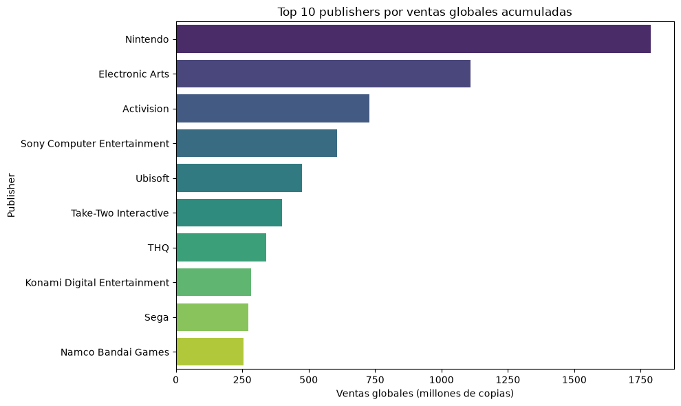

```python
top_publishers_ventas = (
    df_limpio.groupby('Publisher')['Global_Sales']
    .sum()
    .sort_values(ascending=False)
    .head(10)
)

plt.figure(figsize=(10, 6))
sns.barplot(x=top_publishers_ventas.values, y=top_publishers_ventas.index, palette='viridis')
plt.title('Top 10 publishers por ventas globales acumuladas')
plt.xlabel('Ventas globales (millones de copias)')
plt.ylabel('Publisher')
plt.tight_layout()
plt.show()
```

## Distribución de GlobalSales

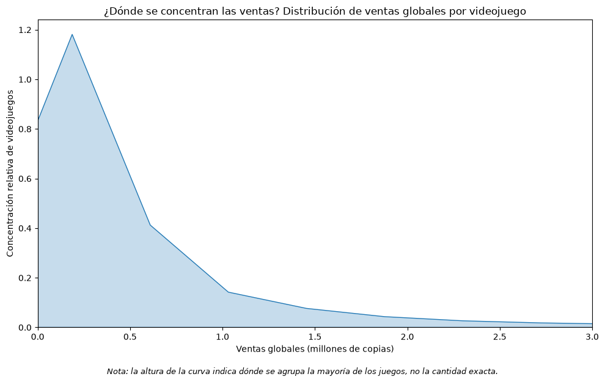

```python
plt.figure(figsize=(10, 6))
sns.kdeplot(df_limpio['Global_Sales'], fill=True)
plt.title('¿Dónde se concentran las ventas? Distribución de ventas globales por videojuego')
plt.xlabel('Ventas globales (millones de copias)')
plt.ylabel('Concentración relativa de videojuegos')
plt.xlim(0, 3)
plt.figtext(0.5, -0.03,
            'Nota: la altura de la curva indica dónde se agrupa la mayoría de los juegos, no la cantidad exacta.',
            ha='center', fontsize=9, style='italic')
plt.tight_layout()
plt.show()
```

## GlobalSales por Género

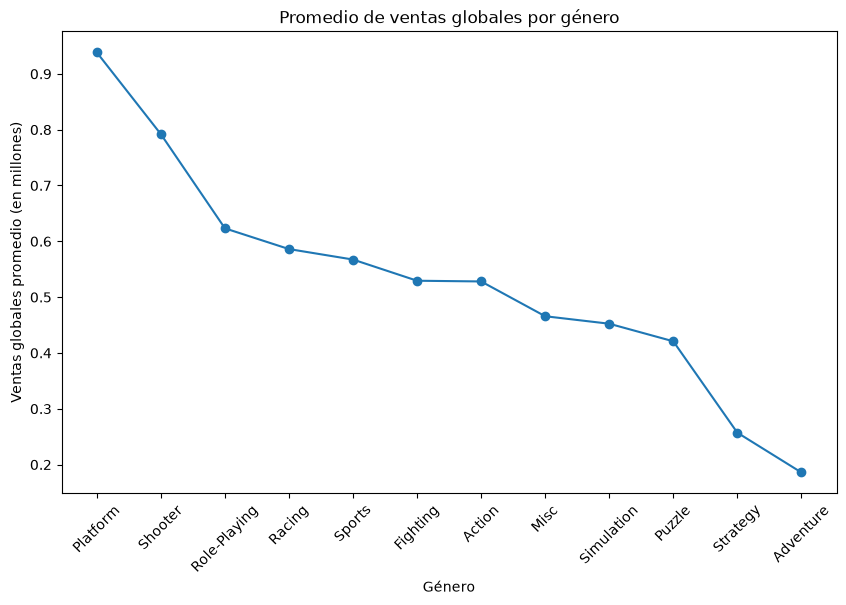

```python
ventas_por_genero = (
    df_limpio.groupby("Genre")["Global_Sales"]
    .mean()
    .sort_values(ascending=False)
)

plt.figure(figsize=(10,6))
plt.plot(ventas_por_genero.index, ventas_por_genero.values, marker="o")
plt.title("Promedio de ventas globales por género")
plt.xlabel("Género")
plt.ylabel("Ventas globales promedio (en millones)")
plt.xticks(rotation=45)
plt.show()
```

## Ventas totales por región

```python
import plotly.express as px

ventas_region = pd.DataFrame({
    'Región': ['América del Norte', 'Europa', 'Japón', 'Resto del mundo'],
    'Ventas': [
        df_limpio['NA_Sales'].sum(),
        df_limpio['EU_Sales'].sum(),
        df_limpio['JP_Sales'].sum(),
        df_limpio['Other_Sales'].sum()
    ],
    'iso_alpha': ['USA', 'FRA', 'JPN', 'BRA']
})

fig = px.choropleth(
    ventas_region,
    locations='iso_alpha',
    color='Ventas',
    hover_name='Región',
    color_continuous_scale='Plasma',
    title='Ventas globales de videojuegos por región (millones de copias)'
)
fig.show(renderer="notebook")
```

[interactive chart not shown]